# Voice User Interfaces - Speech Recognition with Neural Networks

# Made By: Omar Khater

[figure not shown]

- Introduction

- Overview  
- Data description  
- Data Visualization

- Step1: Acoustic Features for Speech Recognition

- Spectrograms  
- Mel-Frequency Cepstral Coefficients (MFCCs)

- Step2: Deep Neural Networks for Acoustic Modeling

- Connectionist Temporal Classification (CTC)  
- Model 0 : RNN  
- Model 1 : RNN + TimeDistributed Dense  
- Model 2 : CNN + RNN + TimeDistributed Dense  
- Model 3 : Deeper RNN + TimeDistributed Dense  
- Model 4 : Bidirectional RNN + TimeDistributed Dense  
- Compare the Models  
- Final Model : CNN + Deep Bidirectional RNN + TimeDistributed Dense

- Step3: Obtain Predictions
- Future work and conclusions

<a id = 'intro'></a>

## Introduction

<a id = 'overview'></a> Automatic speech recognition (ASR) modules has proved indispensability in any Natural Lanugage Processing solution. A deep learning powered automatic speech recognition that accepts raw audio as input and return a predicted transcription of the spoken language is explored in this project.

An *eye-bird's* view on the pipeline used in this project is illustrated below followed by a general description for each part.

[figure not shown]

- **STEP 1:** is a pre-processing step that converts raw audio to one of two feature representations that are commonly used for ASR.
- **STEP 2:** is an acoustic model which accepts audio features as input and returns a probability distribution over all potential transcriptions.
- **STEP 3:** takes the output from the acoustic model and returns a predicted transcription.

### Data description

It is essential to begin by investigating the dataset that will be used to train and evaluate the pipeline. [LibriSpeech](http://www.danielpovey.com/files/2015_icassp_librispeech.pdf) is a large corpus of English-read speech, designed for training and evaluating models for ASR which contains 1000 hours of speech derived from audiobooks. However, a small portion of the data set is used to reduce the computation cost.

Any training example has the following attributes:

- `vis_text` - transcribed text (label) for the training example.
- `vis_raw_audio` - raw audio waveform for the training example.
- `vis_mfcc_feature` - mel-frequency cepstral coefficients (MFCCs) for the training example.
- `vis_spectrogram_feature` - spectrogram for the training example.
- `vis_audio_path` - the file path to the training example.

### Importing necessary libraries

```python
import numpy as np
from data_generator import vis_train_features
from IPython.display import Markdown, display
from data_generator import vis_train_features, plot_raw_audio
from IPython.display import Audio
from data_generator import plot_spectrogram_feature
from data_generator import plot_mfcc_feature
%matplotlib inline

# used with get_predicts function
from data_generator import AudioGenerator
from keras import backend as K
from utils import int_sequence_to_text
from IPython.display import Audio
```

### Run after break

```python
#####################################################################
# RUN THIS CODE CELL IF YOU ARE RESUMING THE NOTEBOOK AFTER A BREAK #
#####################################################################

# allocate 100% of GPU memory (if you like, feel free to change this)
from keras.backend.tensorflow_backend import set_session
import tensorflow as tf
config = tf.ConfigProto()
config.gpu_options.per_process_gpu_memory_fraction = 1
set_session(tf.Session(config=config))

from keras.optimizers import SGD
# watch for any changes in the sample_models module, and reload it automatically
%load_ext autoreload
%autoreload 2
# import NN architectures for speech recognition
from sample_models import *
# import function for training acoustic model
from train_utils import train_model

Features = 'Spectogram'
# Features = 'MFCC'
if Features == 'Spectogram':
    n_input = 161
    Features_Mode = True # train the RNN Model using Spectogram features
elif Feautres == 'MFCC':
    n_input = 13
    Features_Mode = False # train the RNN Model using MFCC features

#RNN_Mode = 'SimpleRNN'
RNN_Mode = 'GRU'
# RNN_Mode = 'LSTM'
n_epochs = 20
learning_rate = .025
Optimizer = SGD( lr = learning_rate, decay = 1e-6, momentum = 0.9, nesterov = True, clipnorm = 5)
Deep_rnn_layers = 3
Units_Multi = [75, 200, 75]
Units_Single = 200
```

<a id = 'visualizing'></a>

### Data visualization

An example of the training set shows the audio waveform along with the corresponding transcript is visualized below where is audio file can be played as well.

```python
# extract label and audio features for a single training example
vis_text, vis_raw_audio, vis_mfcc_feature, vis_spectrogram_feature, vis_audio_path = vis_train_features(index = np.random.randint(low = 0, high = 2023))
```

```
There are 2023 total training examples.
```

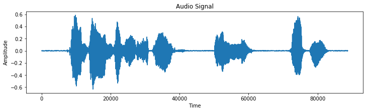

**Shape of Audio Signal** : (88752,)

**Transcript** : oh god give me strength aid me help me

[interactive chart not shown]

```python
# plot audio signal
plot_raw_audio(vis_raw_audio)
# print length of audio signal
display(Markdown('**Shape of Audio Signal** : ' + str(vis_raw_audio.shape)))
# print transcript corresponding to audio clip
display(Markdown('**Transcript** : ' + str(vis_text)))
# play the audio file
Audio(vis_audio_path)
```

## STEP 1: Acoustic Features for Speech Recognition

Two different pre-processing schemas is used to convert the *raw audio* to a *feature representation* that has historically proven successful for **ASR models**. *Moreover*, the acoustic model will accept this feature representation as an input. _Namely_, `Spectograms` and `Mel-Frequency Cepstral Coefficients (MFCCs)` are used to map the input raw audio file into features ready to feed the deep learning models.

<a id = 'spectrograms'></a>

### Spectrograms

The first option for an audio feature representation is the [spectrogram](https://www.youtube.com/watch?v=_FatxGN3vAM). The code for calculating the spectrogram was borrowed from [this repository](https://github.com/baidu-research/ba-dls-deepspeech).  
The code returns the spectrogram as a 2D tensor, where the first (*vertical*) dimension indexes time, and the second (*horizontal*) dimension indexes frequency. To speed the convergence of the algorithm later, the spectrogram is normalized . Note that the mean value hovers around zero in the visualization below, and most entries in the tensor assume values close to zero.)

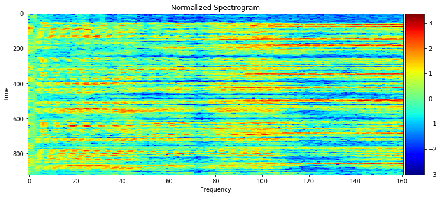

**Shape of Spectrogram** : (920, 161)

```python
# plot normalized spectrogram
plot_spectrogram_feature(vis_spectrogram_feature)
# print shape of spectrogram
display(Markdown('**Shape of Spectrogram** : ' + str(vis_spectrogram_feature.shape)))
```

<a id = 'mfcc'></a>

### Mel-Frequency Cepstral Coefficients (MFCCs)

The second option for an audio feature representation is [MFCCs](https://en.wikipedia.org/wiki/Mel-frequency_cepstrum) where [`python_speech_features`](https://github.com/jameslyons/python_speech_features) is used for implementation. Just as with the spectrogram features, the MFCCs are normalized.

The main idea behind MFCC features is the same as spectrogram features: at each time window, the MFCC feature yields a feature vector that characterizes the sound within the window. Note that the MFCC feature is much lower-dimensional than the spectrogram feature, which could help an acoustic model to avoid overfitting to the training dataset.

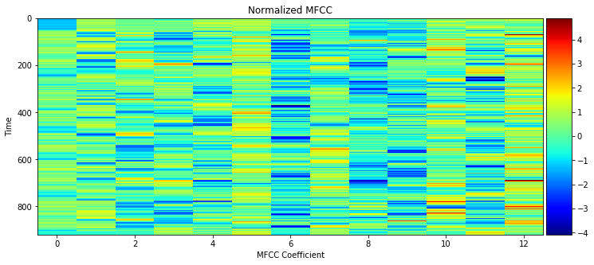

**Shape of MFCC** : (920, 13)

```python
# plot normalized MFCC
plot_mfcc_feature(vis_mfcc_feature)
# print shape of MFCC
display(Markdown('**Shape of MFCC** : ' + str(vis_mfcc_feature.shape)))
```

## STEP 2: Deep Neural Networks for Acoustic Modeling

In this section, various neural network architectures are used for acoustic modeling.

<a id ="CTC"></a>

### Connectionist Temporal Classification (CTC)

The input data in speech recognition is a sequence of observations in the form of frame vectors from regular time intervals. The desired output is a series of symbols: phonemes, graphemes, or words. The basic problem is that the number of frames does not have a predictible correspondence to the number of the output symbols. For example, assume 20ms per frame, the following audio signals of the word "speech" spoken at two different speeds have about 300 frames in the first example and something like 850 frames in the second example, yet they should both be decoded as the six-letter word, "speech"

[figure not shown]

A Connectionist Temporal Classification (CTC) loss function can be calculated to train the network. When combined with the CTC decoding algorithm over the softmax output layer, the sequence-to-sequence transformation is achieved. The details of how this works are in the seminal paper on CTC by Alex Graves: [Graves, Alex, et al. "Connectionist temporal classification: labelling unsegmented sequence data with recurrent neural networks." Proceedings of the 23rd international conference on Machine learning. ACM, 2006.](http://machinelearning.wustl.edu/mlpapers/paper_files/icml2006_GravesFGS06.pdf)

#### CTC Training

Graves derives an objective function to calculate the error between the labels expected and the softmax result. The function calculates all the possible paths and likelihoods for the softmax output layer and calculates the maximum log likelihood for the correct labeling. For example, a correct labeling of a "hello" utterance might have several valid paths with varying probabilities:

<img src="images/hello_CTC.jpg" width = "80%">

All models below are trained the acoustic model with the [CTC loss](http://www.cs.toronto.edu/~graves/icml_2006.pdf) criterion.

### Model 0: RNN

Given their effectiveness in modeling sequential data, the first acoustic model used is an RNN. As shown in the figure below, the RNN takes the time sequence of audio features as an input.

[figure not shown]

At each time step, the speaker pronounces one of 28 possible characters, including each of the 26 letters in the English alphabet, along with a space character (" "), and an apostrophe (').

The output of the RNN at each time step is a vector of probabilities with 29 entries, where the $i$-th entry encodes the probability that the $i$-th character is spoken in the time sequence. (The extra 29th character is an empty "character" used to pad training examples within batches containing uneven lengths). The figure below shows an equivalent, rolled depiction of the RNN that shows the output layer in greater detail.

[figure not shown]

```python
model_0 = simple_rnn_model(input_dim = n_input, mode = RNN_Mode)
```

```
_________________________________________________________________
Layer (type)                 Output Shape              Param #
=================================================================
the_input (InputLayer)       (None, None, 161)         0
_________________________________________________________________
rnn (GRU)                    (None, None, 29)          16617
_________________________________________________________________
softmax (Activation)         (None, None, 29)          0
=================================================================
Total params: 16,617
Trainable params: 16,617
Non-trainable params: 0
_________________________________________________________________
None
```

```python
train_model(input_to_softmax = model_0,
            pickle_path = 'model_0.pickle',
            save_model_path = 'model_0.h5',
            spectrogram = Features_Mode,
            optimizer = Optimizer,
            epochs = n_epochs)
```

### Model 1: RNN + TimeDistributed Dense

In this architecture, [batch normalization](https://arxiv.org/pdf/1510.01378.pdf) is added to the recurrent layer to reduce training times. Additionally, the `TimeDistributed` layer is used to find more complex patterns in the dataset. The unrolled snapshot of the architecture is depicted below.

[figure not shown]

The next figure shows an equivalent, rolled depiction of the RNN that shows the (`TimeDistrbuted`) dense and output layers in greater detail.

[figure not shown]

```python
model_1 = rnn_model(input_dim = n_input, # change to 13 if you would like to use MFCC features
                    units = Units_Single,
                    activation = 'relu',
                    mode = RNN_Mode)
```

```
_________________________________________________________________
Layer (type)                 Output Shape              Param #
=================================================================
the_input (InputLayer)       (None, None, 161)         0
_________________________________________________________________
rnn (GRU)                    (None, None, 200)         217200
_________________________________________________________________
batch_normalization_1 (Batch (None, None, 200)         800
_________________________________________________________________
time_distributed_1 (TimeDist (None, None, 29)          5829
_________________________________________________________________
softmax (Activation)         (None, None, 29)          0
=================================================================
Total params: 223,829
Trainable params: 223,429
Non-trainable params: 400
_________________________________________________________________
None
```

```python
from workspace_utils import active_session

with active_session():

    train_model(input_to_softmax = model_1,
                pickle_path ='model_1.pickle',
                save_model_path = 'model_1.h5',
                spectrogram = Features_Mode,
                optimizer = Optimizer,
                epochs = n_epochs)
```

### Model 2: CNN + RNN + TimeDistributed Dense

This architecture adds an additional level of complexity, by introducing a [1D convolution layer](https://keras.io/layers/convolutional/#conv1d).

[figure not shown]

```python
model_2 = cnn_rnn_model(input_dim = n_input,
                        filters = 200,
                        kernel_size = 11,
                        conv_stride = 2,
                        conv_border_mode = 'valid',
                        units = Units_Single,
                        mode = RNN_Mode)
```

```
_________________________________________________________________
Layer (type)                 Output Shape              Param #
=================================================================
the_input (InputLayer)       (None, None, 161)         0
_________________________________________________________________
conv1d (Conv1D)              (None, None, 200)         354400
_________________________________________________________________
bn_conv_1d (BatchNormalizati (None, None, 200)         800
_________________________________________________________________
rnn (GRU)                    (None, None, 200)         240600
_________________________________________________________________
batch_normalization_1 (Batch (None, None, 200)         800
_________________________________________________________________
time_distributed_3 (TimeDist (None, None, 29)          5829
_________________________________________________________________
softmax (Activation)         (None, None, 29)          0
=================================================================
Total params: 602,429
Trainable params: 601,629
Non-trainable params: 800
_________________________________________________________________
None
```

```python
from workspace_utils import active_session

with active_session():
    train_model(input_to_softmax = model_2,
                pickle_path = 'model_2.pickle',
                save_model_path = 'model_2.h5',
                spectrogram = Features_Mode,
                optimizer = Optimizer,
                epochs = n_epochs)
```

### Model 3: Deeper RNN + TimeDistributed Dense

This architecture utilizes a variable number `recur_layers` of recurrent layers. The figure below shows the architecture that should be returned if `recur_layers=2`. In the figure, the output sequence of the first recurrent layer is used as input for the next recurrent layer.

[figure not shown]

The model below is trained with 3 RNN layers

```python
model_3 = deep_rnn_model(input_dim = n_input,
                         recur_layers = Deep_rnn_layers,
                         units = Units_Multi,
                         mode = RNN_Mode)
```

```
_________________________________________________________________
Layer (type)                 Output Shape              Param #
=================================================================
the_input (InputLayer)       (None, None, 161)         0
_________________________________________________________________
rnn_0 (GRU)                  (None, None, 75)          53325
_________________________________________________________________
bn_rnn_0 (BatchNormalization (None, None, 75)          300
_________________________________________________________________
rnn_1 (GRU)                  (None, None, 200)         165600
_________________________________________________________________
bn_rnn_1 (BatchNormalization (None, None, 200)         800
_________________________________________________________________
rnn_2 (GRU)                  (None, None, 75)          62100
_________________________________________________________________
bn_rnn_2 (BatchNormalization (None, None, 75)          300
_________________________________________________________________
time_distributed_3 (TimeDist (None, None, 29)          2204
_________________________________________________________________
softmax (Activation)         (None, None, 29)          0
=================================================================
Total params: 284,629
Trainable params: 283,929
Non-trainable params: 700
_________________________________________________________________
None
```

```python
from workspace_utils import active_session

with active_session():

    train_model(input_to_softmax = model_3,
                pickle_path = 'model_3.pickle',
                save_model_path = 'model_3.h5',
                spectrogram = Features_Mode,
                optimizer = Optimizer,
                epochs = n_epochs)
```

### Model 4: Bidirectional RNN + TimeDistributed Dense

A single bidirectional RNN layer , before a (`TimeDistributed`) dense layer is experimented below. The added value of a bidirectional RNN is described well in [this paper](http://www.cs.toronto.edu/~hinton/absps/DRNN_speech.pdf).

> One shortcoming of conventional RNNs is that they are only able to make use of previous context. In speech recognition, where whole utterances are transcribed at once, there is no reason not to exploit future context as well. Bidirectional RNNs (BRNNs) do this by processing the data in both directions with two separate hidden layers which are then fed forwards to the same output layer.

[figure not shown]

```python
model_4 = bidirectional_rnn_model(input_dim = n_input,
                                  units = Units_Single, mode = RNN_Mode)
```

```
_________________________________________________________________
Layer (type)                 Output Shape              Param #
=================================================================
the_input (InputLayer)       (None, None, 161)         0
_________________________________________________________________
bidirectional_1 (Bidirection (None, None, 400)         434400
_________________________________________________________________
time_distributed_1 (TimeDist (None, None, 29)          11629
_________________________________________________________________
softmax (Activation)         (None, None, 29)          0
=================================================================
Total params: 446,029
Trainable params: 446,029
Non-trainable params: 0
_________________________________________________________________
None
```

```python
from workspace_utils import active_session

with active_session():

    train_model(input_to_softmax = model_4,
                pickle_path = 'model_4.pickle',
                save_model_path = 'model_4.h5',
                spectrogram = Features_Mode,
                optimizer = Optimizer,
                epochs = n_epochs)
```

### Compare the Models

To evaluate the performance of the drafted deep learning models, the training and validation loss are plotted for each model.

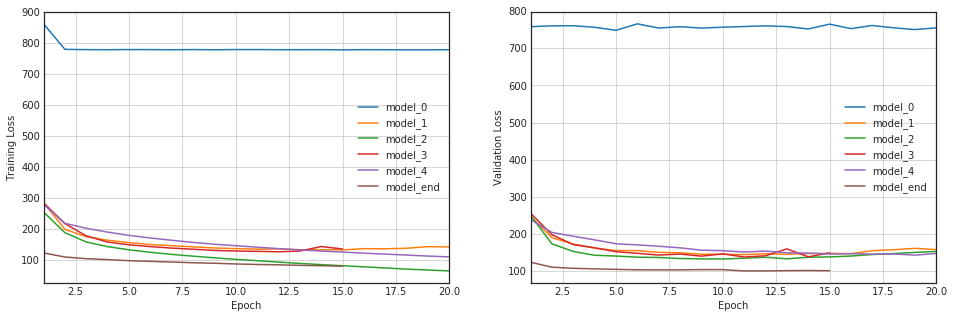

```python
from glob import glob
import numpy as np
import _pickle as pickle
import seaborn as sns
import matplotlib.pyplot as plt
%matplotlib inline
sns.set_style(style='white')

# obtain the paths for the saved model history
all_pickles = sorted(glob("results/*.pickle"))
# extract the name of each model
model_names = [item[8:-7] for item in all_pickles]
# extract the loss history for each model
valid_loss = [pickle.load( open( i, "rb" ) )['val_loss'] for i in all_pickles]
train_loss = [pickle.load( open( i, "rb" ) )['loss'] for i in all_pickles]
# save the number of epochs used to train each model
num_epochs = [len(valid_loss[i]) for i in range(len(valid_loss))]

fig = plt.figure(figsize=(16,5))

# plot the training loss vs. epoch for each model
ax1 = fig.add_subplot(121)
for i in range(len(all_pickles)):
    ax1.plot(np.linspace(1, num_epochs[i], num_epochs[i]),
            train_loss[i], label=model_names[i])
# clean up the plot
ax1.legend()
ax1.set_xlim([1, max(num_epochs)])
ax1.grid()
plt.xlabel('Epoch')
plt.ylabel('Training Loss')

# plot the validation loss vs. epoch for each model
ax2 = fig.add_subplot(122)
for i in range(len(all_pickles)):
    ax2.plot(np.linspace(1, num_epochs[i], num_epochs[i]),
            valid_loss[i], label=model_names[i])
# clean up the plot
ax2.legend()
ax2.set_xlim([1, max(num_epochs)])
ax2.grid()
plt.xlabel('Epoch')
plt.ylabel('Validation Loss')
plt.show()
```

**Question 1:** Use the plot above to analyze the performance of each of the attempted architectures. Which performs best? Provide an explanation regarding why you think some models perform better than others.

### (IMPLEMENTATION) Final Model

Now that you've tried out many sample models, use what you've learned to draft your own architecture! While your final acoustic model should not be identical to any of the architectures explored above, you are welcome to merely combine the explored layers above into a deeper architecture. It is **NOT** necessary to include new layer types that were not explored in the notebook.

However, if you would like some ideas for even more layer types, check out these ideas for some additional, optional extensions to your model:

- If you notice your model is overfitting to the training dataset, consider adding **dropout**! To add dropout to [recurrent layers](https://faroit.github.io/keras-docs/1.0.2/layers/recurrent/), pay special attention to the `dropout_W` and `dropout_U` arguments. This [paper](http://arxiv.org/abs/1512.05287) may also provide some interesting theoretical background.
- If you choose to include a convolutional layer in your model, you may get better results by working with **dilated convolutions**. If you choose to use dilated convolutions, make sure that you are able to accurately calculate the length of the acoustic model's output in the `model.output_length` lambda function. You can read more about dilated convolutions in Google's [WaveNet paper](https://arxiv.org/abs/1609.03499). For an example of a speech-to-text system that makes use of dilated convolutions, check out this GitHub [repository](https://github.com/buriburisuri/speech-to-text-wavenet). You can work with dilated convolutions [in Keras](https://keras.io/layers/convolutional/) by paying special attention to the `padding` argument when you specify a convolutional layer.
- If your model makes use of convolutional layers, why not also experiment with adding **max pooling**? Check out [this paper](https://arxiv.org/pdf/1701.02720.pdf) for example architecture that makes use of max pooling in an acoustic model.
- So far, you have experimented with a single bidirectional RNN layer. Consider stacking the bidirectional layers, to produce a [deep bidirectional RNN](https://www.cs.toronto.edu/~graves/asru_2013.pdf)!

All models that you specify in this repository should have `output_length` defined as an attribute. This attribute is a lambda function that maps the (temporal) length of the input acoustic features to the (temporal) length of the output softmax layer. This function is used in the computation of CTC loss; to see this, look at the `add_ctc_loss` function in `train_utils.py`. To see where the `output_length` attribute is defined for the models in the code, take a look at the `sample_models.py` file. You will notice this line of code within most models:

```
model.output_length = lambda x: x
```

The acoustic model that incorporates a convolutional layer (`cnn_rnn_model`) has a line that is a bit different:

```
model.output_length = lambda x: cnn_output_length(
        x, kernel_size, conv_border_mode, conv_stride)
```

In the case of models that use purely recurrent layers, the lambda function is the identity function, as the recurrent layers do not modify the (temporal) length of their input tensors. However, convolutional layers are more complicated and require a specialized function (`cnn_output_length` in `sample_models.py`) to determine the temporal length of their output.

You will have to add the `output_length` attribute to your final model before running the code cell below. Feel free to use the `cnn_output_length` function, if it suits your model.

```python
# specify the model
model_end = final_model(input_dim = n_input,
                        recur_layers = Deep_rnn_layers,
                        units = Units_Multi,
                        filters = 200,
                        kernel_size = 11,
                        conv_stride = 2,
                        conv_border_mode = 'valid', output_dim = 29, mode = 'GRU')
```

```
_________________________________________________________________
Layer (type)                 Output Shape              Param #
=================================================================
the_input (InputLayer)       (None, None, 161)         0
_________________________________________________________________
conv1d (Conv1D)              (None, None, 200)         354400
_________________________________________________________________
bn_conv_1d (BatchNormalizati (None, None, 200)         800
_________________________________________________________________
bidirectional_4 (Bidirection (None, None, 150)         124200
_________________________________________________________________
bn_rnn_0 (BatchNormalization (None, None, 150)         600
_________________________________________________________________
bidirectional_5 (Bidirection (None, None, 400)         421200
_________________________________________________________________
bn_rnn_1 (BatchNormalization (None, None, 400)         1600
_________________________________________________________________
bidirectional_6 (Bidirection (None, None, 150)         214200
_________________________________________________________________
bn_rnn_2 (BatchNormalization (None, None, 150)         600
_________________________________________________________________
time_distributed_2 (TimeDist (None, None, 29)          4379
_________________________________________________________________
softmax (Activation)         (None, None, 29)          0
=================================================================
Total params: 1,121,979
Trainable params: 1,120,179
Non-trainable params: 1,800
_________________________________________________________________
None
```

Please execute the code cell below to train the neural network you specified in `input_to_softmax`. After the model has finished training, the model is [saved](https://keras.io/getting-started/faq/#how-can-i-save-a-keras-model) in the HDF5 file `model_end.h5`. The loss history is [saved](https://wiki.python.org/moin/UsingPickle) in `model_end.pickle`. You are welcome to tweak any of the optional parameters while calling the `train_model` function, but this is not required.

```python
from workspace_utils import active_session

with active_session():

    train_model(input_to_softmax = model_end,
            pickle_path = 'model_end.pickle',
            save_model_path = 'model_end.h5',
            spectrogram = Features_Mode,
            optimizer = Optimizer,
            epochs = n_epochs)
```

**Question 2:** Describe your final model architecture and your reasoning at each step.

**Answer:** Based on the results so far, the final model build upon models above and included the ideas that showed a potential. Spesifically, it uses CNN to extract patterns from the audio features before feeding it deep bidirectional RNN netowrk. In addition, the final model used early stopping as well regularized RNN layers to reduce overfitting. The RNN unit used in all models are Gate Rectified Units (GRUs).

## STEP 3: Obtain Predictions

We have written a function for you to decode the predictions of your acoustic model. To use the function, please execute the code cell below.

```python
import numpy as np
from data_generator import AudioGenerator
from keras import backend as K
from utils import int_sequence_to_text
from IPython.display import Audio

def get_predictions(index, partition, input_to_softmax, model_path):
    """ Print a model's decoded predictions
    Params:
        index (int): The example you would like to visualize
        partition (str): One of 'train' or 'validation'
        input_to_softmax (Model): The acoustic model
        model_path (str): Path to saved acoustic model's weights
    """
    # load the train and test data
    data_gen = AudioGenerator()
    data_gen.load_train_data()
    data_gen.load_validation_data()

    # obtain the true transcription and the audio features
    if partition == 'validation':
        transcr = data_gen.valid_texts[index]
        audio_path = data_gen.valid_audio_paths[index]
        data_point = data_gen.normalize(data_gen.featurize(audio_path))
    elif partition == 'train':
        transcr = data_gen.train_texts[index]
        audio_path = data_gen.train_audio_paths[index]
        data_point = data_gen.normalize(data_gen.featurize(audio_path))
    else:
        raise Exception('Invalid partition!  Must be "train" or "validation"')

    # obtain and decode the acoustic model's predictions
    input_to_softmax.load_weights(model_path)
    prediction = input_to_softmax.predict(np.expand_dims(data_point, axis=0))
    output_length = [input_to_softmax.output_length(data_point.shape[0])]
    pred_ints = (K.eval(K.ctc_decode(
                prediction, output_length)[0][0])+1).flatten().tolist()

    # play the audio file, and display the true and predicted transcriptions
    print('-'*80)
    Audio(audio_path)
    print('True transcription:\n' + '\n' + transcr)
    print('-'*80)
    print('Predicted transcription:\n' + '\n' + ''.join(int_sequence_to_text(pred_ints)))
    print('-'*80)
```

Use the code cell below to obtain the transcription predicted by your final model for the first example in the training dataset.

```python
get_predictions(index=0,
                partition = 'train',
                input_to_softmax = model_2,
                model_path = './results/model_2.h5')
```

```
--------------------------------------------------------------------------------
True transcription:

her father is a most remarkable person to say the least
--------------------------------------------------------------------------------
Predicted transcription:

her fonther os o mot remarkoble pirsond to sa thet lest
--------------------------------------------------------------------------------
```

```python
get_predictions(index=0,
                partition='train',
                input_to_softmax = model_end,
                model_path = './results/model_end.h5')
```

```
--------------------------------------------------------------------------------
True transcription:

her father is a most remarkable person to say the least
--------------------------------------------------------------------------------
Predicted transcription:

her fothers am mos fer markcabl purcsin to saye the lest
--------------------------------------------------------------------------------
```

Use the next code cell to visualize the model's prediction for the first example in the validation dataset.

```python
get_predictions(index = 0,
                partition = 'validation',
                input_to_softmax = model_2,
                model_path = './results/model_2.h5')
```

```
--------------------------------------------------------------------------------
True transcription:

the bogus legislature numbered thirty six members
--------------------------------------------------------------------------------
Predicted transcription:

the botis lid is latiured nonvger dhirtisacs menvers
--------------------------------------------------------------------------------
```

```python
get_predictions(index=0,
                partition = 'validation',
                input_to_softmax = model_end,
                model_path = './results/model_end.h5')
```

```
--------------------------------------------------------------------------------
True transcription:

the bogus legislature numbered thirty six members
--------------------------------------------------------------------------------
Predicted transcription:

the bo is logaslagure noverde thirty sixs emvers
--------------------------------------------------------------------------------
```

<a id = 'future'></a>

## Conclusions and Future Work

### Limitations and conclusions

- The end model reveals superior performance over all previous models which indicates moving in the right direction toward more robust models.
- Some networks trained before adding the early stop callback. Thus, some models show clear signs of overfitting.
- The loss value still quite large indicating the complexity of the problem. However, networks with convolutional neural networks showed potential for extracting relevent patterns from audio features that help the acoustic model produce more advanced transcriptions.
- The training data is truncated to be able to produce meaningful results in this project. However, adding more data could introduce more advanced transcriptions.
- The models so far were not experimented with test (unseen) data which is expected to perform similar or even worst.
- Including of bidirectional RNN showed slight improvment over similar unidirectional RNN structure. Nevertheless, more deep RNN does not seem to be helpful in learning process.
- Adding dropout regularization as well as early stopping mechanism helped reduce overfitting significantly while training the final model.
- State-of-the-art models take 3-6 weeks on a single GPU which is out of scope for this educational project.

### Future Work

- Adding language model to the decoder which is the defacto standard way to improve the results nowadays.
- Expriement with deep learning algorithms that accepts raw audio input directly (i.e., without feature extraction step)
- ُExperiment the models using LSTM instead of GRU.
- Add dilated convolutions and max pooling layer to the convoluation network that works on feature extraction.
- Feed all models with MFCC features instead of Spectograms to reduce overfitting.